# Introduction to Spatial Data in R

**In this workshop we will:**  
- Import addresses and geocode them  
- Plot addresses  
- Create buffers around addresses

**STEP 1: Set Working Directory**  
Go to Session->Set Working Directory->Choose Directory or use setwd() function as below

```r
setwd("~/Desktop/RSpatial-master")
```

**STEP 2: Install Required Packages**  
*if you haven’t installed them already*

```r
# install.packages('tidygeocoder')
# install.packages('sp')
# install.packages("Rcpp") #required by units & sf packages
# install.packages('units') #required by sf package
# install.packages('sf')
# install.packages("magrittr")
```

**STEP 3: Load Required Packages**

```r
library(tidygeocoder)
library(sp)
library(magrittr)
library(sf)
```

```r
addresses <- read.csv('example_addresses.csv', header = T,
                      stringsAsFactors = FALSE)
# look at the data
print(addresses)
```

```
##            name                                               address     zip
## 1   SP Building           7141 Rue Sherbrooke O, Montreal, QC, Canada H4B 2A7
## 2 Hall Building 1455 Boulevard de Maisonneuve O, Montreal, QC, Canada H3G 1M8
```

**STEP 5: Determine Longitude and Latitude of Addresses**  
and save in object named ‘place’

```r
place <- geocode(addresses, address = address, method = 'arcgis', lat = latitude , long = longitude)
```

```
## Passing 2 addresses to the ArcGIS single address geocoder
```

```
## Query completed in: 0.3 seconds
```

**STEP 6: Add Longitude and Latitude columns back to data frame’addresses’**

```r
addresses$Latitude = place$latitude
addresses$Longitude = place$longitude
```

**STEP 7: Convert data frame ‘addresses’ to a shapfile and plot**

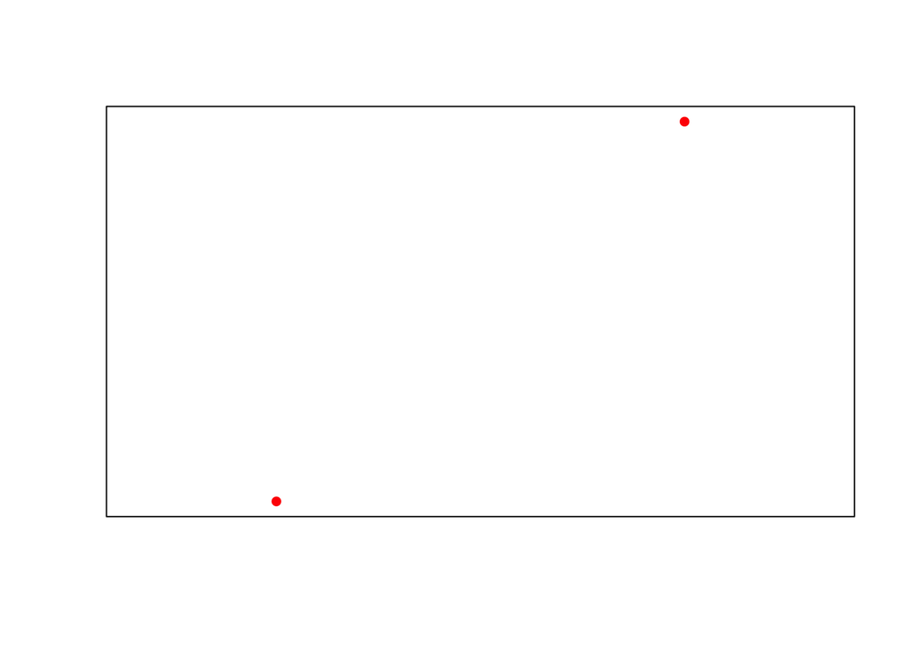

```r
# duplicate addresses
addr.sp = addresses
# using 'coordinates' function, define which columns contain longitude and latitude coordinates
coordinates(addr.sp)<-~Longitude+Latitude
# tell R what the coordinate system these points use
proj4string(addr.sp) = CRS("+proj=longlat +ellps=WGS84 +datum=WGS84 +no_defs")
#plot
plot(addr.sp, pch = 16, col = "red")
box(col = 'black')
```

**STEP 8: Import map of Montreal & plot**  
download from: https://donnees.montreal.ca/ville-de-montreal/polygones-arrondissements

```r
mtl <- st_read('limadmin-shp/LIMADMIN.shp')
```

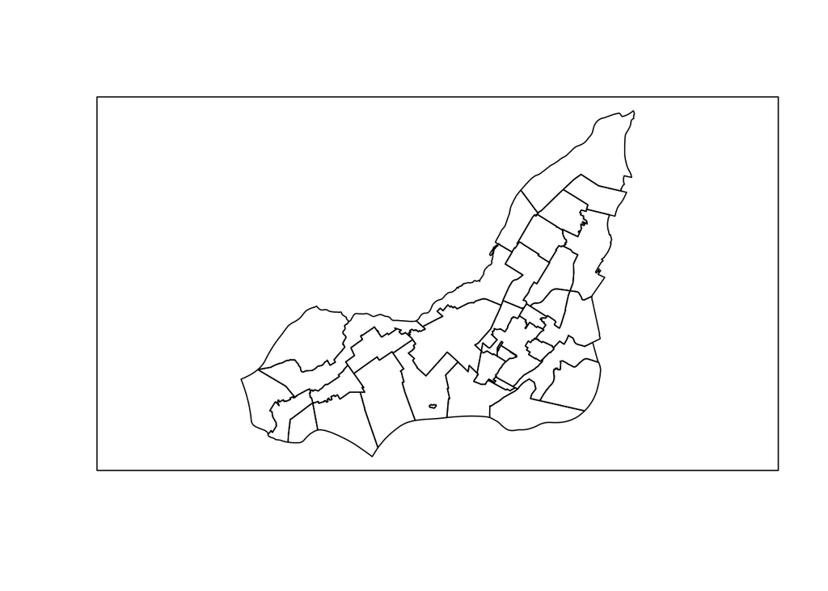

```r
plot(mtl%>% st_geometry)
box(col = 'black')
```

**STEP 9: Plot addresses on map of Montreal**

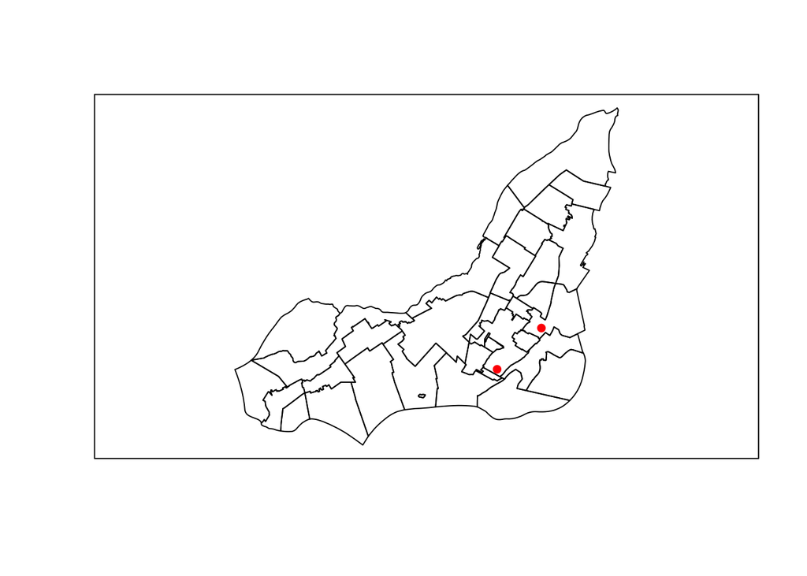

```r
# convert address sp file to sf
addr.sf = st_as_sf(addr.sp)
# plot
plot(mtl%>% st_geometry)
plot(addr.sf %>% st_geometry, col = "red", pch = 16, add = T)
box(col = 'black')
```

**STEP 10: Draw a 500m buffer around each address**  
*When you need to calculate distances, you first have to transform your data:* geographic coordinate system -> projected coordinate system

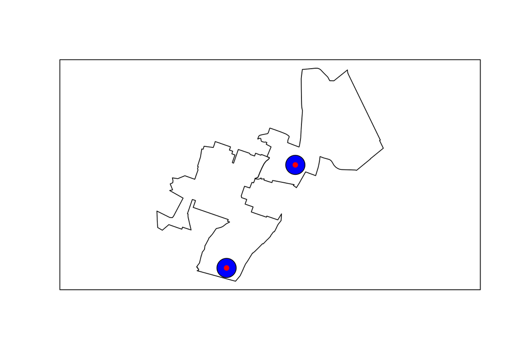

```r
#ftransform
addr.sf.pr = st_transform(addr.sf, crs = 5070)
mtl.pr = st_transform(mtl, crs = 5070)

# draw buffers around the addresses
buffers = st_buffer(addr.sf.pr, dist = 500)

#plot but subset to 2 arrondisements to zoom in in so buffers are visible
plot(mtl.pr[mtl.pr$NOM == "Côte-des-Neiges-Notre-Dame-de-Grâce" | mtl.pr$NOM =="Ville-Marie" ,] %>% st_geometry)
plot(buffers%>% st_geometry,col = 'blue', add = T)
plot(addr.sf.pr%>% st_geometry,col = 'red', pch = 16, size = 1 , add = TRUE )
box(col = 'black')
```